# tz_gaming

## TZ Gaming Modeling

```python
import pandas as pd
import pyrsm as rsm
from sklearn.linear_model import LogisticRegression
# Load the tz_gaming dataset
# The path 'data/tz_gaming.parquet' should be replaced with the actual path to your .parquet file
tz_gaming = pd.read_parquet('data/tz_gaming.parquet')
tz_gaming.head()
```

|  | training | inum | click | time | time_fct | app | mobile_os | impup | clup | ctrup | ... | ctrua | imput | clut | ctrut | imppat | clpat | ctrpat | rnd | pred_vneta | id |
| --- | --- | --- | --- | --- | --- | --- | --- | --- | --- | --- | --- | --- | --- | --- | --- | --- | --- | --- | --- | --- | --- |
| 0 | train | I7 | no | 9 | 9 | app8 | ios | 439 | 2 | 0.455581 | ... | 0.000000 | 25 | 0 | 0.000000 | 71 | 1 | 1.408451 | -1.207066 | 0.003961 | id247135 |
| 1 | train | I23 | no | 15 | 15 | app1 | ios | 64 | 0 | 0.000000 | ... | 0.000000 | 7 | 0 | 0.000000 | 67312 | 1069 | 1.588127 | 0.277429 | 0.003961 | id245079 |
| 2 | train | I28 | no | 12 | 12 | app5 | ios | 80 | 0 | 0.000000 | ... | 6.578947 | 94 | 0 | 0.000000 | 331 | 1 | 0.302115 | 1.084441 | 0.003961 | id927245 |
| 3 | train | I30 | no | 19 | 19 | app1 | ios | 25 | 0 | 0.000000 | ... | 0.000000 | 19 | 0 | 0.000000 | 71114 | 1001 | 1.407599 | -2.345698 | 0.018965 | id922188 |
| 4 | train | I35 | no | 24 | 24 | app1 | android | 3834 | 29 | 0.756390 | ... | 0.689655 | 329 | 4 | 1.215805 | 183852 | 2317 | 1.260253 | 0.429125 | 0.003961 | id355833 |

5 rows × 22 columns

```python
#tz_gaming = pd.read_parquet("data/tz_gaming.parquet")
```

```python
# Creating a copy of the original DataFrame
original_data = tz_gaming.copy()
```

```python
# Convert 'click' to binary format
tz_gaming['click'] = tz_gaming['click'].map({'yes': 1, 'no': 0})
```

```python
tz_gaming[tz_gaming['click'] == 1]. count()
```

```
training      1045
inum          1045
click         1045
time          1045
time_fct      1045
app           1045
mobile_os     1045
impup         1045
clup          1045
ctrup         1045
impua         1045
clua          1045
ctrua         1045
imput         1045
clut          1045
ctrut         1045
imppat        1045
clpat         1045
ctrpat        1045
rnd           1045
pred_vneta    1045
id            1045
dtype: int64
```

```python
# Convert 'click' column to numeric data type
tz_gaming['click'] = pd.to_numeric(tz_gaming['click'], errors='coerce')
```

```python
# Split the data into training and test sets
train_data = tz_gaming[tz_gaming['training'] == 'train']
test_data = tz_gaming[tz_gaming['training'] == 'test']
```

```python
test_data[test_data['click'] == 1]. count()
```

```
training      271
inum          271
click         271
time          271
time_fct      271
app           271
mobile_os     271
impup         271
clup          271
ctrup         271
impua         271
clua          271
ctrua         271
imput         271
clut          271
ctrut         271
imppat        271
clpat         271
ctrpat        271
rnd           271
pred_vneta    271
id            271
dtype: int64
```

```python
test_data[test_data['click'] == 0]. count()
```

```
training      27682
inum          27682
click         27682
time          27682
time_fct      27682
app           27682
mobile_os     27682
impup         27682
clup          27682
ctrup         27682
impua         27682
clua          27682
ctrua         27682
imput         27682
clut          27682
ctrut         27682
imppat        27682
clpat         27682
ctrpat        27682
rnd           27682
pred_vneta    27682
id            27682
dtype: int64
```

```python
# # Check if the training data contains any samples
# if len(train_data) > 0:
#     # Initialize and train the logistic regression model
#     model = LogisticRegression(max_iter=1000)  # Increase max_iter if necessary
#     model.fit(train_data[feature_columns], train_data['click'])

#     # Generate predictions for the test set
#     test_data.loc[:, 'pred_logit'] = model.predict_proba(test_data[feature_columns])[:, 1]
# else:
#     print("Training data is empty. Please ensure that the 'train_data' DataFrame contains at least one sample.")
```

```python
from sklearn.linear_model import LogisticRegression

# Assuming 'tz_gaming' is your main DataFrame and 'train_data' is a subset of 'tz_gaming' where 'training' is 'train'.
# Define your feature columns: you need to replace this with your actual feature columns
feature_columns = ['time', 'impup', 'clup', 'ctrup', 'impua', 'clua', 'ctrua']

# Initialize and train the logistic regression model
# Use max_iter=1000 or increase if the model does not converge
model = LogisticRegression(max_iter=1000)
model.fit(train_data[feature_columns], train_data['click'])

# Create a copy of the test_data subset to avoid SettingWithCopyWarning
test_data = tz_gaming[tz_gaming['training'] == 'test'].copy()

# Generate predictions for the test set using .loc to ensure operations are done correctly
test_data.loc[:, 'pred_logit'] = model.predict_proba(test_data[feature_columns])[:, 1]

# Now 'test_data' has a new column 'pred_logit' with the predictions.
# Predict probabilities for training and test data
train_data.loc[:, 'pred_logit'] = model.predict_proba(train_data[feature_columns])[:, 1]

tz_gaming['pred_logit'] = model.predict_proba(tz_gaming[['time', 'impup', 'clup', 'ctrup', 'impua', 'clua', 'ctrua']])[:, 1]
```

```python
test_data_copy = test_data.copy()
```

```python
test_data['click'].values
```

```
array([0, 0, 0, ..., 0, 0, 0], dtype=int64)
```

```python
print(test_data[['pred_logit']].head())
print(train_data[['pred_logit']].head())
```

```
       pred_logit
87535    0.004882
87536    0.009100
87537    0.000169
87538    0.003130
87539    0.014118
   pred_logit
0    0.009838
1    0.010532
2    0.008531
3    0.010468
4    0.001273
```

```python
print(test_data['pred_logit'].describe())
print(train_data['pred_logit'].describe())
```

```
count    2.795300e+04
mean     9.161329e-03
std      2.570466e-02
min      4.575172e-19
25%      3.709950e-03
50%      7.503115e-03
75%      1.076062e-02
max      9.632570e-01
Name: pred_logit, dtype: float64
count    8.753500e+04
mean     8.841676e-03
std      2.206010e-02
min      2.201145e-17
25%      4.136296e-03
50%      7.571512e-03
75%      1.054726e-02
max      9.714417e-01
Name: pred_logit, dtype: float64
```

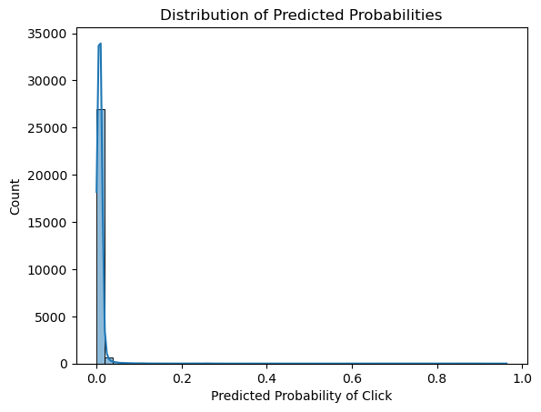

```python
import seaborn as sns
import matplotlib.pyplot as plt

sns.histplot(test_data['pred_logit'], bins=50, kde=True)
plt.xlabel('Predicted Probability of Click')
plt.ylabel('Count')
plt.title('Distribution of Predicted Probabilities')
plt.show()
```

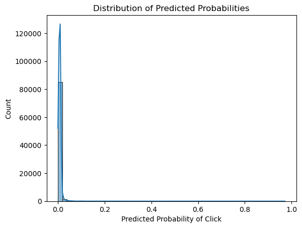

```python
import seaborn as sns
import matplotlib.pyplot as plt

sns.histplot(train_data['pred_logit'], bins=50, kde=True)
plt.xlabel('Predicted Probability of Click')
plt.ylabel('Count')
plt.title('Distribution of Predicted Probabilities')
plt.show()
```

```python
from sklearn.metrics import accuracy_score, confusion_matrix

accuracy = accuracy_score(test_data['click'], test_data['pred_logit'].round())
cm = confusion_matrix(test_data['click'], test_data['pred_logit'].round())

print(f'Accuracy: {accuracy}')
print(f'Confusion Matrix:\n{cm}')
```

```
Accuracy: 0.9897327657138769
Confusion Matrix:
[[27664    18]
 [  269     2]]
```

The accuracy is approximately 98.97%, which means that our model correctly predicted the outcomes (both clicks and no-clicks) for about 98.97% of the cases in your test data.

True Negatives (TN): 27664 - The number of correctly predicted no-clicks. False Positives (FP): 18 - The number of no-clicks incorrectly predicted as clicks. False Negatives (FN): 269 - The number of clicks incorrectly predicted as no-clicks. True Positives (TP): 2 - The number of correctly predicted clicks.

The confusion matrix indicates that your model is excellent at identifying no-clicks (true negatives) but not as good at identifying clicks (true positives). This is evident from the large number of true negatives (27664) compared to a very small number of true positives (2).

The number of false negatives (269) is relatively high, indicating that many actual clicks were missed by your model and predicted as no-clicks. This might be a significant issue if the primary goal is to identify as many clicks as possible (e.g., in ad targeting).

The very low number of true positives (2) suggests that your model might be very conservative in predicting clicks. This could be due to the model heavily favoring the majority class (no-clicks) in an imbalanced dataset, leading to a high overall accuracy but poor performance in correctly identifying the minority class (clicks).

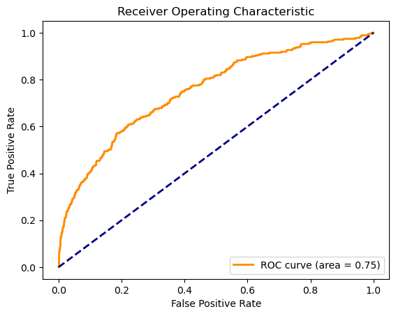

```python
from sklearn.metrics import roc_curve, auc

# Calculate the ROC curve points
fpr, tpr, thresholds = roc_curve(test_data['click'], test_data['pred_logit'])

# Calculate the AUC (Area under the ROC Curve)
roc_auc = auc(fpr, tpr)

plt.figure()
plt.plot(fpr, tpr, color='darkorange', lw=2, label='ROC curve (area = %0.2f)' % roc_auc)
plt.plot([0, 1], [0, 1], color='navy', lw=2, linestyle='--')
plt.xlabel('False Positive Rate')
plt.ylabel('True Positive Rate')
plt.title('Receiver Operating Characteristic')
plt.legend(loc="lower right")
plt.show()
```

```python
# Define a threshold for classifying a prediction as a click
threshold = 0.16

# Create a new column for binary predictions
test_data['predictions_binary'] = (test_data['pred_logit'] >= threshold).astype(int)
```

```python
# Define the cost per thousand impressions (CPM)
cost_per_thousand_impressions = 10  # This value is given in your case study

# Calculate cost per single impression
cost_per_impression = cost_per_thousand_impressions / 1000

# Define the number of impressions for the upcoming campaign
number_of_impressions = 20000000  # 20-million impression campaign

# Define the conversion rate from click to sign-up
conversion_rate = 0.05  # 5% conversion rate given in your case study

# Define the Customer Lifetime Value (CLV) for a user who signs up
clv = 25  # The expected CLV given in your case study

# Assuming 'predictions_binary' is a column in your 'test_data' DataFrame with binary predictions (1 for click, 0 for no click)
# Calculate the expected number of conversions
expected_conversions = number_of_impressions * test_data['predictions_binary'].mean() * conversion_rate

# Calculate the expected revenue from conversions
expected_revenue = expected_conversions * clv

# Calculate the total cost of the campaign
total_cost = (number_of_impressions * cost_per_impression)  # Add additional costs if there are any

# Calculate the profit
profit = expected_revenue - total_cost

# Calculate the Return on Marketing Expenditures (ROME)
ROME = profit / total_cost

# Print the results
print(f"Cost per impression: ${cost_per_impression}")
print(f"Number of impressions: {number_of_impressions}")
print(f"Expected conversions: {expected_conversions}")
print(f"Expected revenue: ${expected_revenue:.2f}")
print(f"Total cost: ${total_cost:.2f}")
print(f"Profit: ${profit:.2f}")
print(f"Return on Marketing Expenditures (ROME): {ROME:.2%}")
```

[output not shown]

```python
from sklearn.linear_model import LogisticRegression

# Assuming tz_gaming is your DataFrame and is already loaded
# Filter the training data
train_data_rnd = tz_gaming[tz_gaming['training'] == 'train']
test_data_rnd = tz_gaming[tz_gaming['training'] == 'test']

# Logistic regression with 'rnd' as predictor for training data
lr_rnd = LogisticRegression()
lr_rnd.fit(train_data[['rnd']], train_data['click'])

# Predict probabilities for all data (both train and test)
tz_gaming['pred_rnd'] = lr_rnd.predict_proba(tz_gaming[['rnd']])[:, 1]
```